# **Career Recommendation in Data Science & its Sub-Field**

Given the exponential growth of data science in the present era, our objective is to analyze the demand for data science and its subfield requirements. By doing so, we aim to address the significant challenges that data science candidates often encounter when transitioning to different cities or exploring other subfields within data science, such as machine learning and data analysis.

## 1 - PRIOR KNOWLEDGE

### 1.1 Key Factors of the domain

> Analyzing data science salaries in recent past years involves considering these factors in combination to provide a comprehensive understanding of the salary landscape in the field. Data scientists and analysts use statistical techniques and data modeling to extract meaningful insights from salary data, considering these variables and their interactions to draw accurate conclusions about salary trends and patterns.

### 1.2 Business Questions

Following are the business question which we're going to answer by our insights through data science process.

- **Job Recommendation:** Business Question: Can we suggest a job based on the user's current employment title or experience ?
- **Salary Recommendation:** Business Question: Is it possible for us to suggest salaries based on experience?
- **Location-Based Analysis:** Business Question: How does the geographic location impact career opportunities and salaries in Data Science?
- **Analysis of Career Growth:** Business Question: What are the various factors that influence the growth of salary in the field of Data Science, including job title and location?
- **Salary Prediction:** Business Question: Can future salaries for data science be predicted by considering factors like experience and job title?

### 1.3 Data Collection

This is the prior knowledge phase to gather relevant data about career recommendation of data science, including its subfield such as data analyst, machine learning etc. We have sourced this data from kaggle to ensure that we meet our requirements then we can able to answer the business questions that are necessary in the data science process.

> Sources from which we collect data

Kaggle - https://www.kaggle.com/datasets

## 2 - DATA PREPARATION

> Our Dataset contains 3755 rows × 11 columns which include featuers of data science and these attributes has relationship among them and we'll explore the data by visualization with various libraries available in python to visualize data.

### 2.1 Importing Libraries

We need to import libraries that are required to process dataset, which will be using to clean data and which are using to visualize data.

```python
#Following libraries will be used to perform data exploration
import pandas as pd
import numpy as np
import seaborn as sns                       #Visualisation
import matplotlib.pyplot as plt             #Visualisation
%matplotlib inline
sns.set(color_codes=True)
from sklearn import preprocessing
from sklearn.feature_extraction.text import CountVectorizer, TfidfVectorizer
from sklearn.metrics.pairwise import cosine_similarity
from sklearn.preprocessing import StandardScaler
from sklearn.linear_model import LinearRegression,LogisticRegression
from sklearn.ensemble import RandomForestRegressor
from sklearn.model_selection import train_test_split
from sklearn.metrics import mean_squared_error, r2_score, accuracy_score, precision_score, recall_score, f1_score, confusion_matrix, classification_report
from sklearn import  metrics
```

### 2.2 Loading the data into the data frame.

Loading the data into a data frame using the Python library pandas is the initial and crucial step in data exploration or exploratory data analysis. Hence, we must read our CSV file named "ds_salaries2023.csv" that contains a collection of rows and columns and is located in the directory.

```python
from google.colab import drive
drive.mount('/content/drive')
```

```python
df = pd.read_csv("/content/drive/MyDrive/DSDataSet/ds_salaries2023.csv")
```

Now, we will demonstrate the size of our existing unstructured data set prior to cleaning, which will facilitate the comparison of its size post data preparation.

```python
df.size
```

```
41305
```

```python
a, b = df.shape
print("Dataset shape: rows {} columns {}".format(a, b))
```

```
Dataset shape: rows 3755 columns 11
```

The execution of the given line of code will generate the visualization of the dataset, displaying its rows and columns.

```python
df #just to show the consitency of the data we're going to show the top 5 and bottom 5 rows of the dataset
```

|  | work_year | experience_level | employment_type | job_title | salary | salary_currency | salary_in_usd | employee_residence | remote_ratio | company_location | company_size |
| --- | --- | --- | --- | --- | --- | --- | --- | --- | --- | --- | --- |
| 0 | 2023 | SE | FT | Principal Data Scientist | 80000 | EUR | 85847 | ES | 100 | ES | L |
| 1 | 2023 | MI | CT | ML Engineer | 30000 | USD | 30000 | US | 100 | US | S |
| 2 | 2023 | MI | CT | ML Engineer | 25500 | USD | 25500 | US | 100 | US | S |
| 3 | 2023 | SE | FT | Data Scientist | 175000 | USD | 175000 | CA | 100 | CA | M |
| 4 | 2023 | SE | FT | Data Scientist | 120000 | USD | 120000 | CA | 100 | CA | M |
| ... | ... | ... | ... | ... | ... | ... | ... | ... | ... | ... | ... |
| 3750 | 2020 | SE | FT | Data Scientist | 412000 | USD | 412000 | US | 100 | US | L |
| 3751 | 2021 | MI | FT | Principal Data Scientist | 151000 | USD | 151000 | US | 100 | US | L |
| 3752 | 2020 | EN | FT | Data Scientist | 105000 | USD | 105000 | US | 100 | US | S |
| 3753 | 2020 | EN | CT | Business Data Analyst | 100000 | USD | 100000 | US | 100 | US | L |
| 3754 | 2021 | SE | FT | Data Science Manager | 7000000 | INR | 94665 | IN | 50 | IN | L |

3755 rows × 11 columns

Furthermore, we will present the dataset's information, which will help us to understand the dataset.

```python
df.info()
```

```
<class 'pandas.core.frame.DataFrame'>
RangeIndex: 3755 entries, 0 to 3754
Data columns (total 11 columns):
 #   Column              Non-Null Count  Dtype
---  ------              --------------  -----
 0   work_year           3755 non-null   int64
 1   experience_level    3755 non-null   object
 2   employment_type     3755 non-null   object
 3   job_title           3755 non-null   object
 4   salary              3755 non-null   int64
 5   salary_currency     3755 non-null   object
 6   salary_in_usd       3755 non-null   int64
 7   employee_residence  3755 non-null   object
 8   remote_ratio        3755 non-null   int64
 9   company_location    3755 non-null   object
 10  company_size        3755 non-null   object
dtypes: int64(4), object(7)
memory usage: 322.8+ KB
```

```python
#to get the count of the dataset
df.count()
```

```
work_year             3755
experience_level      3755
employment_type       3755
job_title             3755
salary                3755
salary_currency       3755
salary_in_usd         3755
employee_residence    3755
remote_ratio          3755
company_location      3755
company_size          3755
dtype: int64
```

The DataFrame contains data description and generates statistical summaries that depict the distribution's central tendency and shape, excluding NaN values. Additionally, the percentile indicates the number of values that are less than the specified percentile, provided that the DataFrame comprises numerical data.

```python
df.describe(include="all")
```

|  | work_year | experience_level | employment_type | job_title | salary | salary_currency | salary_in_usd | employee_residence | remote_ratio | company_location | company_size |
| --- | --- | --- | --- | --- | --- | --- | --- | --- | --- | --- | --- |
| count | 3755.000000 | 3755 | 3755 | 3755 | 3.755000e+03 | 3755 | 3755.000000 | 3755 | 3755.000000 | 3755 | 3755 |
| unique | NaN | 4 | 4 | 93 | NaN | 20 | NaN | 78 | NaN | 72 | 3 |
| top | NaN | SE | FT | Data Engineer | NaN | USD | NaN | US | NaN | US | M |
| freq | NaN | 2516 | 3718 | 1040 | NaN | 3224 | NaN | 3004 | NaN | 3040 | 3153 |
| mean | 2022.373635 | NaN | NaN | NaN | 1.906956e+05 | NaN | 137570.389880 | NaN | 46.271638 | NaN | NaN |
| std | 0.691448 | NaN | NaN | NaN | 6.716765e+05 | NaN | 63055.625278 | NaN | 48.589050 | NaN | NaN |
| min | 2020.000000 | NaN | NaN | NaN | 6.000000e+03 | NaN | 5132.000000 | NaN | 0.000000 | NaN | NaN |
| 25% | 2022.000000 | NaN | NaN | NaN | 1.000000e+05 | NaN | 95000.000000 | NaN | 0.000000 | NaN | NaN |
| 50% | 2022.000000 | NaN | NaN | NaN | 1.380000e+05 | NaN | 135000.000000 | NaN | 0.000000 | NaN | NaN |
| 75% | 2023.000000 | NaN | NaN | NaN | 1.800000e+05 | NaN | 175000.000000 | NaN | 100.000000 | NaN | NaN |
| max | 2023.000000 | NaN | NaN | NaN | 3.040000e+07 | NaN | 450000.000000 | NaN | 100.000000 | NaN | NaN |

### 2.3 Data Type Verification

It is important to note that the dataset may consist of attributes of different types. In situations where the data is categorical, it is crucial to transform them into continuous numeric attributes.

```python
df.dtypes
```

```
work_year              int64
experience_level      object
employment_type       object
job_title             object
salary                 int64
salary_currency       object
salary_in_usd          int64
employee_residence    object
remote_ratio           int64
company_location      object
company_size          object
dtype: object
```

As we can see above all of the availble columns are in appropriate data type, so in our case there is no need to convert any data type.

### 2.4 Remove irrelevant columns

We will keep only the essential columns required to address our business questions, disregarding any irrelevant columns. If there are any irrelevant columns, we will eliminate all of them.

```python
#This line will display all the columns present in our dataset,
#after which we will eliminate any unnecessary ones.
df.columns
```

```
Index(['work_year', 'experience_level', 'employment_type', 'job_title',
       'salary', 'salary_currency', 'salary_in_usd', 'employee_residence',
       'remote_ratio', 'company_location', 'company_size'],
      dtype='object')
```

> According to our business questions we don't need to have following coloumns
> - Salary
> - salary_currency
> - remote_ratio
> - company_size

>   ```
>   With the help of the below lines of code, we shall get rid of the columns that mentioned above.
>   ```

```python
df = df.drop(['salary','salary_currency','remote_ratio','company_size'], 1, errors = "ignore" )
#display top 5 rows including columns name to make sure irrelevant column has been dropped.
df.head(6)
```

|  | work_year | experience_level | employment_type | job_title | salary_in_usd | employee_residence | company_location |
| --- | --- | --- | --- | --- | --- | --- | --- |
| 0 | 2023 | SE | FT | Principal Data Scientist | 85847 | ES | ES |
| 1 | 2023 | MI | CT | ML Engineer | 30000 | US | US |
| 2 | 2023 | MI | CT | ML Engineer | 25500 | US | US |
| 3 | 2023 | SE | FT | Data Scientist | 175000 | CA | CA |
| 4 | 2023 | SE | FT | Data Scientist | 120000 | CA | CA |
| 5 | 2023 | SE | FT | Applied Scientist | 222200 | US | US |

*Reason for eliminating salary column*

Since we are solely focusing on salary in USD, there is no requirement for other currencies and their conversion. Therefore, we're going to remove salary and its currency columns which are not in USD.

### 2.5 Renaming the columns

This step is necessary in case the column names are difficult to comprehend so while renaming the column to enhance the readability of the dataset.

```python
#This line will display all the columns present in our dataset, Afterward, we shall proceed to rename the columns
#that do not adhere to proper naming conventions.
df.columns
```

```
Index(['work_year', 'experience_level', 'employment_type', 'job_title',
       'salary_in_usd', 'employee_residence', 'company_location'],
      dtype='object')
```

```python
#The code provided below will effectively rename all columns with inappropriate names.
df=df.rename(columns={'salary_in_usd': 'salary_USD','job_title': 'employment_title',
                      'company_location':'employment_location','employee_residence':
                      'employee_location'})
df.columns
```

```
Index(['work_year', 'experience_level', 'employment_type', 'employment_title',
       'salary_USD', 'employee_location', 'employment_location'],
      dtype='object')
```

### 2.6 Checking for Null/Missing values

It is imperative to examine the presence of null or missing values in our dataset, as they can potentially lead to inaccurate outcomes when addressing the business query.

```python
#checking the shape of the data
df.shape
```

```
(3755, 7)
```

```python
#checking for null/missing values
df.isnull().sum()
```

```
work_year              0
experience_level       0
employment_type        0
employment_title       0
salary_USD             0
employee_location      0
employment_location    0
dtype: int64
```

The dataset's structure is evident the absence of any null or missing values in its columns.

### 2.7 Dropping the duplicate

Data cleaning is an essential task in which a significant dataset may include duplicate rows, posing a challenge in obtaining accurate answers to business inquiries. Consequently, it is necessary to eliminate all duplicate values from the dataset.

```python
duplicate_rows_df=df[df.duplicated()]
print("number of duplicated rows: ",duplicate_rows_df.shape)
```

```
number of duplicated rows:  (1381, 7)
```

> **Duplicate rows** To ensure that the duplicate rows are identical and can be removed from our dataset, it is necessary to display the dataframe containing these duplicate rows.

```python
duplicate_rows_df_soting = duplicate_rows_df.sort_values(by=['work_year', 'experience_level', 'employment_type', 'employment_title', 'salary_USD' , 'employment_location'], ascending = False)
duplicate_rows_df_soting
```

|  | work_year | experience_level | employment_type | employment_title | salary_USD | employee_location | employment_location |
| --- | --- | --- | --- | --- | --- | --- | --- |
| 1249 | 2023 | SE | FT | Research Scientist | 253750 | ES | ES |
| 956 | 2023 | SE | FT | Research Scientist | 250000 | US | US |
| 1751 | 2023 | SE | FT | Research Scientist | 250000 | US | US |
| 1560 | 2023 | SE | FT | Research Scientist | 210000 | US | US |
| 1706 | 2023 | SE | FT | Research Scientist | 210000 | US | US |
| ... | ... | ... | ... | ... | ... | ... | ... |
| 3709 | 2021 | MI | FT | Data Scientist | 90734 | DE | DE |
| 3586 | 2021 | MI | FT | Data Engineer | 200000 | US | US |
| 3627 | 2021 | EN | FT | Data Scientist | 100000 | US | US |
| 3630 | 2021 | EN | FT | Data Science Consultant | 76833 | DE | DE |
| 3120 | 2020 | EN | FT | Data Engineer | 13493 | IN | IN |

1381 rows × 7 columns

> **Removing duplicate rows** To eliminate duplicate rows from our dataset, the provided code snippet is utilized for removing duplication from the dataset.

```python
df = df.drop_duplicates()
a, b = df.shape
print("Dataset shape: rows {} columns {}".format(a, b))
```

```
Dataset shape: rows 2374 columns 7
```

### 2.8 Column values analysis

Analyzing a large number of categorical values poses a significant challenge. Therefore, in order to simplify the process, we will consider grouping these values together if they become too numerous.

```python
#unique values in each column
df.nunique()
```

```
work_year                 4
experience_level          4
employment_type           4
employment_title         93
salary_USD             1035
employee_location        78
employment_location      72
dtype: int64
```

#### 2.8.a Experience Level

```python
df['experience_level'].unique()
```

```
array(['SE', 'MI', 'EN', 'EX'], dtype=object)
```

*Better Readability*

*Upon analyzing the level of expertise in our datset, we have come to the realization that it is necessary to assign appropriate names to the column values.*

```python
experience_level_dict = { "EN":"Entry-Level / Junior",
                         "MI":"Mid-Level / Intermediate",
                         "SE": "Senior-Level / Expert",
                         "EX":"Executive-Level / Director"
}
df['experience_level'] = df['experience_level'].map(experience_level_dict)
```

```python
df['experience_level'].unique()
```

```
array(['Senior-Level / Expert', 'Mid-Level / Intermediate',
       'Entry-Level / Junior', 'Executive-Level / Director'], dtype=object)
```

#### 2.8.b Employment Type

```python
df['employment_type'].unique()
```

```
array(['FT', 'CT', 'FL', 'PT'], dtype=object)
```

*Better Readability*

*Upon analyzing the column Employment Type in our datset, we have come to the realization that it is necessary to assign appropriate names to the column values.*

```python
emp_type_dict = { "PT":"Part-Time",
                 "FT":"Full-Time",
                 "CT":"Contract",
                 "FL":"Freelance"
}

df['employment_type'] = df['employment_type'].map(emp_type_dict)
```

```python
df['employment_type'].unique()
```

```
array(['Full-Time', 'Contract', 'Freelance', 'Part-Time'], dtype=object)
```

#### 2.8.c Employee Location

```python
df['employee_location'].unique()
```

```
array(['ES', 'US', 'CA', 'DE', 'GB', 'NG', 'IN', 'HK', 'PT', 'NL', 'CH',
       'CF', 'FR', 'AU', 'FI', 'UA', 'IE', 'IL', 'GH', 'AT', 'CO', 'SG',
       'SE', 'SI', 'MX', 'UZ', 'BR', 'TH', 'HR', 'PL', 'KW', 'VN', 'CY',
       'AR', 'AM', 'BA', 'KE', 'GR', 'MK', 'LV', 'RO', 'PK', 'IT', 'MA',
       'LT', 'BE', 'AS', 'IR', 'HU', 'SK', 'CN', 'CZ', 'CR', 'TR', 'CL',
       'PR', 'DK', 'BO', 'PH', 'DO', 'EG', 'ID', 'AE', 'MY', 'JP', 'EE',
       'HN', 'TN', 'RU', 'DZ', 'IQ', 'BG', 'JE', 'RS', 'NZ', 'MD', 'LU',
       'MT'], dtype=object)
```

*Better Readability*

Upon analyzing the column Employee residence/location in our datset, we have come to the realization that it is necessary to assign appropriate names to the column values.

```python
residence_location = {
	'AD': 'Andorra',
	'AE': 'United Arab Emirates',
	'AF': 'Afghanistan',
	'AG': 'Antigua & Barbuda',
	'AI': 'Anguilla',
	'AL': 'Albania',
	'AM': 'Armenia',
	'AN': 'Netherlands Antilles',
	'AO': 'Angola',
	'AQ': 'Antarctica',
	'AR': 'Argentina',
	'AS': 'American Samoa',
	'AT': 'Austria',
	'AU': 'Australia',
	'AW': 'Aruba',
	'AZ': 'Azerbaijan',
	'BA': 'Bosnia and Herzegovina',
	'BB': 'Barbados',
	'BD': 'Bangladesh',
	'BE': 'Belgium',
	'BF': 'Burkina Faso',
	'BG': 'Bulgaria',
	'BH': 'Bahrain',
	'BI': 'Burundi',
	'BJ': 'Benin',
	'BM': 'Bermuda',
	'BN': 'Brunei Darussalam',
	'BO': 'Bolivia',
	'BR': 'Brazil',
	'BS': 'Bahama',
	'BT': 'Bhutan',
	'BU': 'Burma (no longer exists)',
	'BV': 'Bouvet Island',
	'BW': 'Botswana',
	'BY': 'Belarus',
	'BZ': 'Belize',
	'CA': 'Canada',
	'CC': 'Cocos (Keeling) Islands',
	'CF': 'Central African Republic',
	'CG': 'Congo',
	'CH': 'Switzerland',
	'CI': 'Côte D\'ivoire (Ivory Coast)',
	'CK': 'Cook Iislands',
	'CL': 'Chile',
	'CM': 'Cameroon',
	'CN': 'China',
	'CO': 'Colombia',
	'CR': 'Costa Rica',
	'CS': 'Czechoslovakia (no longer exists)',
	'CU': 'Cuba',
	'CV': 'Cape Verde',
	'CX': 'Christmas Island',
	'CY': 'Cyprus',
	'CZ': 'Czech Republic',
	'DD': 'German Democratic Republic (no longer exists)',
	'DE': 'Germany',
	'DJ': 'Djibouti',
	'DK': 'Denmark',
	'DM': 'Dominica',
	'DO': 'Dominican Republic',
	'DZ': 'Algeria',
	'EC': 'Ecuador',
	'EE': 'Estonia',
	'EG': 'Egypt',
	'EH': 'Western Sahara',
	'ER': 'Eritrea',
	'ES': 'Spain',
	'ET': 'Ethiopia',
	'FI': 'Finland',
	'FJ': 'Fiji',
	'FK': 'Falkland Islands (Malvinas)',
	'FM': 'Micronesia',
	'FO': 'Faroe Islands',
	'FR': 'France',
	'FX': 'France, Metropolitan',
	'GA': 'Gabon',
	'GB': 'United Kingdom (Great Britain)',
	'GD': 'Grenada',
	'GE': 'Georgia',
	'GF': 'French Guiana',
	'GH': 'Ghana',
	'GI': 'Gibraltar',
	'GL': 'Greenland',
	'GM': 'Gambia',
	'GN': 'Guinea',
	'GP': 'Guadeloupe',
	'GQ': 'Equatorial Guinea',
	'GR': 'Greece',
	'GS': 'South Georgia and the South Sandwich Islands',
	'GT': 'Guatemala',
	'GU': 'Guam',
	'GW': 'Guinea-Bissau',
	'GY': 'Guyana',
	'HK': 'Hong Kong',
	'HM': 'Heard & McDonald Islands',
	'HN': 'Honduras',
	'HR': 'Croatia',
	'HT': 'Haiti',
	'HU': 'Hungary',
	'ID': 'Indonesia',
	'IE': 'Ireland',
	'IL': 'Israel',
	'IN': 'India',
	'IO': 'British Indian Ocean Territory',
	'IQ': 'Iraq',
	'IR': 'Islamic Republic of Iran',
	'IS': 'Iceland',
	'IT': 'Italy',
	'JM': 'Jamaica',
	'JO': 'Jordan',
	'JP': 'Japan',
	'KE': 'Kenya',
	'KG': 'Kyrgyzstan',
	'KH': 'Cambodia',
	'KI': 'Kiribati',
	'KM': 'Comoros',
	'KN': 'St. Kitts and Nevis',
	'KP': 'Korea, Democratic People\'s Republic of',
	'KR': 'Korea, Republic of',
	'KW': 'Kuwait',
	'KY': 'Cayman Islands',
	'KZ': 'Kazakhstan',
	'LA': 'Lao People\'s Democratic Republic',
	'LB': 'Lebanon',
	'LC': 'Saint Lucia',
	'LI': 'Liechtenstein',
	'LK': 'Sri Lanka',
	'LR': 'Liberia',
	'LS': 'Lesotho',
	'LT': 'Lithuania',
	'LU': 'Luxembourg',
	'LV': 'Latvia',
	'LY': 'Libyan Arab Jamahiriya',
	'MA': 'Morocco',
	'MC': 'Monaco',
	'MD': 'Moldova, Republic of',
	'MG': 'Madagascar',
	'MH': 'Marshall Islands',
	'ML': 'Mali',
	'MN': 'Mongolia',
	'MM': 'Myanmar',
	'MO': 'Macau',
	'MP': 'Northern Mariana Islands',
	'MQ': 'Martinique',
	'MR': 'Mauritania',
	'MS': 'Monserrat',
	'MT': 'Malta',
	'MU': 'Mauritius',
	'MV': 'Maldives',
	'MW': 'Malawi',
	'MX': 'Mexico',
	'MY': 'Malaysia',
	'MZ': 'Mozambique',
	'NA': 'Namibia',
	'NC': 'New Caledonia',
	'NE': 'Niger',
	'NF': 'Norfolk Island',
	'NG': 'Nigeria',
	'NI': 'Nicaragua',
	'NL': 'Netherlands',
	'NO': 'Norway',
	'NP': 'Nepal',
	'NR': 'Nauru',
	'NT': 'Neutral Zone (no longer exists)',
	'NU': 'Niue',
	'NZ': 'New Zealand',
	'OM': 'Oman',
	'PA': 'Panama',
	'PE': 'Peru',
	'PF': 'French Polynesia',
	'PG': 'Papua New Guinea',
	'PH': 'Philippines',
	'PK': 'Pakistan',
	'PL': 'Poland',
	'PM': 'St. Pierre & Miquelon',
	'PN': 'Pitcairn',
	'PR': 'Puerto Rico',
	'PT': 'Portugal',
	'PW': 'Palau',
	'PY': 'Paraguay',
	'QA': 'Qatar',
	'RE': 'Réunion',
	'RO': 'Romania',
	'RU': 'Russian Federation',
	'RW': 'Rwanda',
	'SA': 'Saudi Arabia',
	'SB': 'Solomon Islands',
	'SC': 'Seychelles',
	'SD': 'Sudan',
	'SE': 'Sweden',
	'SG': 'Singapore',
	'SH': 'St. Helena',
	'SI': 'Slovenia',
	'SJ': 'Svalbard & Jan Mayen Islands',
	'SK': 'Slovakia',
	'SL': 'Sierra Leone',
	'SM': 'San Marino',
	'SN': 'Senegal',
	'SO': 'Somalia',
	'SR': 'Suriname',
	'ST': 'Sao Tome & Principe',
	'SU': 'Union of Soviet Socialist Republics (no longer exists)',
	'SV': 'El Salvador',
	'SY': 'Syrian Arab Republic',
	'SZ': 'Swaziland',
	'TC': 'Turks & Caicos Islands',
	'TD': 'Chad',
	'TF': 'French Southern Territories',
	'TG': 'Togo',
	'TH': 'Thailand',
	'TJ': 'Tajikistan',
	'TK': 'Tokelau',
	'TM': 'Turkmenistan',
	'TN': 'Tunisia',
	'TO': 'Tonga',
	'TP': 'East Timor',
	'TR': 'Turkey',
	'TT': 'Trinidad & Tobago',
	'TV': 'Tuvalu',
	'TW': 'Taiwan, Province of China',
	'TZ': 'Tanzania, United Republic of',
	'UA': 'Ukraine',
	'UG': 'Uganda',
	'UM': 'United States Minor Outlying Islands',
	'US': 'United States of America',
	'UY': 'Uruguay',
	'UZ': 'Uzbekistan',
	'VA': 'Vatican City State (Holy See)',
	'VC': 'St. Vincent & the Grenadines',
	'VE': 'Venezuela',
	'VG': 'British Virgin Islands',
	'VI': 'United States Virgin Islands',
	'VN': 'Viet Nam',
	'VU': 'Vanuatu',
	'WF': 'Wallis & Futuna Islands',
	'WS': 'Samoa',
	'YD': 'Democratic Yemen (no longer exists)',
	'YE': 'Yemen',
	'YT': 'Mayotte',
	'YU': 'Yugoslavia',
	'ZA': 'South Africa',
	'ZM': 'Zambia',
	'ZR': 'Zaire',
	'ZW': 'Zimbabwe',
	'ZZ': 'Unknown or unspecified country',
}
df['employee_location'] = df['employee_location'].map(residence_location)
```

```python
df['employee_location'].unique()
```

```
array(['Spain', 'United States of America', 'Canada', 'Germany',
       'United Kingdom (Great Britain)', 'Nigeria', 'India', 'Hong Kong',
       'Portugal', 'Netherlands', 'Switzerland',
       'Central African Republic', 'France', 'Australia', 'Finland',
       'Ukraine', 'Ireland', 'Israel', 'Ghana', 'Austria', 'Colombia',
       'Singapore', 'Sweden', 'Slovenia', 'Mexico', 'Uzbekistan',
       'Brazil', 'Thailand', 'Croatia', 'Poland', 'Kuwait', 'Viet Nam',
       'Cyprus', 'Argentina', 'Armenia', 'Bosnia and Herzegovina',
       'Kenya', 'Greece', nan, 'Latvia', 'Romania', 'Pakistan', 'Italy',
       'Morocco', 'Lithuania', 'Belgium', 'American Samoa',
       'Islamic Republic of Iran', 'Hungary', 'Slovakia', 'China',
       'Czech Republic', 'Costa Rica', 'Turkey', 'Chile', 'Puerto Rico',
       'Denmark', 'Bolivia', 'Philippines', 'Dominican Republic', 'Egypt',
       'Indonesia', 'United Arab Emirates', 'Malaysia', 'Japan',
       'Estonia', 'Honduras', 'Tunisia', 'Russian Federation', 'Algeria',
       'Iraq', 'Bulgaria', 'New Zealand', 'Moldova, Republic of',
       'Luxembourg', 'Malta'], dtype=object)
```

#### 2.8.d Employment Location

```python
df['employment_location'].unique()
```

```
array(['ES', 'US', 'CA', 'DE', 'GB', 'NG', 'IN', 'HK', 'NL', 'CH', 'CF',
       'FR', 'FI', 'UA', 'IE', 'IL', 'GH', 'CO', 'SG', 'AU', 'SE', 'SI',
       'MX', 'BR', 'PT', 'RU', 'TH', 'HR', 'VN', 'EE', 'AM', 'BA', 'KE',
       'GR', 'MK', 'LV', 'RO', 'PK', 'IT', 'MA', 'PL', 'AL', 'AR', 'LT',
       'AS', 'CR', 'IR', 'BS', 'HU', 'AT', 'SK', 'CZ', 'TR', 'PR', 'DK',
       'BO', 'PH', 'BE', 'ID', 'EG', 'AE', 'LU', 'MY', 'HN', 'JP', 'DZ',
       'IQ', 'CN', 'NZ', 'CL', 'MD', 'MT'], dtype=object)
```

*Better Readability*

Upon analyzing the column Employment location in our datset, we have come to the realization that it is necessary to assign appropriate names to the column values.

```python
residence_location = {
	'AD': 'Andorra',
	'AE': 'United Arab Emirates',
	'AF': 'Afghanistan',
	'AG': 'Antigua & Barbuda',
	'AI': 'Anguilla',
	'AL': 'Albania',
	'AM': 'Armenia',
	'AN': 'Netherlands Antilles',
	'AO': 'Angola',
	'AQ': 'Antarctica',
	'AR': 'Argentina',
	'AS': 'American Samoa',
	'AT': 'Austria',
	'AU': 'Australia',
	'AW': 'Aruba',
	'AZ': 'Azerbaijan',
	'BA': 'Bosnia and Herzegovina',
	'BB': 'Barbados',
	'BD': 'Bangladesh',
	'BE': 'Belgium',
	'BF': 'Burkina Faso',
	'BG': 'Bulgaria',
	'BH': 'Bahrain',
	'BI': 'Burundi',
	'BJ': 'Benin',
	'BM': 'Bermuda',
	'BN': 'Brunei Darussalam',
	'BO': 'Bolivia',
	'BR': 'Brazil',
	'BS': 'Bahama',
	'BT': 'Bhutan',
	'BU': 'Burma (no longer exists)',
	'BV': 'Bouvet Island',
	'BW': 'Botswana',
	'BY': 'Belarus',
	'BZ': 'Belize',
	'CA': 'Canada',
	'CC': 'Cocos (Keeling) Islands',
	'CF': 'Central African Republic',
	'CG': 'Congo',
	'CH': 'Switzerland',
	'CI': 'Côte D\'ivoire (Ivory Coast)',
	'CK': 'Cook Iislands',
	'CL': 'Chile',
	'CM': 'Cameroon',
	'CN': 'China',
	'CO': 'Colombia',
	'CR': 'Costa Rica',
	'CS': 'Czechoslovakia (no longer exists)',
	'CU': 'Cuba',
	'CV': 'Cape Verde',
	'CX': 'Christmas Island',
	'CY': 'Cyprus',
	'CZ': 'Czech Republic',
	'DD': 'German Democratic Republic (no longer exists)',
	'DE': 'Germany',
	'DJ': 'Djibouti',
	'DK': 'Denmark',
	'DM': 'Dominica',
	'DO': 'Dominican Republic',
	'DZ': 'Algeria',
	'EC': 'Ecuador',
	'EE': 'Estonia',
	'EG': 'Egypt',
	'EH': 'Western Sahara',
	'ER': 'Eritrea',
	'ES': 'Spain',
	'ET': 'Ethiopia',
	'FI': 'Finland',
	'FJ': 'Fiji',
	'FK': 'Falkland Islands (Malvinas)',
	'FM': 'Micronesia',
	'FO': 'Faroe Islands',
	'FR': 'France',
	'FX': 'France, Metropolitan',
	'GA': 'Gabon',
	'GB': 'United Kingdom (Great Britain)',
	'GD': 'Grenada',
	'GE': 'Georgia',
	'GF': 'French Guiana',
	'GH': 'Ghana',
	'GI': 'Gibraltar',
	'GL': 'Greenland',
	'GM': 'Gambia',
	'GN': 'Guinea',
	'GP': 'Guadeloupe',
	'GQ': 'Equatorial Guinea',
	'GR': 'Greece',
	'GS': 'South Georgia and the South Sandwich Islands',
	'GT': 'Guatemala',
	'GU': 'Guam',
	'GW': 'Guinea-Bissau',
	'GY': 'Guyana',
	'HK': 'Hong Kong',
	'HM': 'Heard & McDonald Islands',
	'HN': 'Honduras',
	'HR': 'Croatia',
	'HT': 'Haiti',
	'HU': 'Hungary',
	'ID': 'Indonesia',
	'IE': 'Ireland',
	'IL': 'Israel',
	'IN': 'India',
	'IO': 'British Indian Ocean Territory',
	'IQ': 'Iraq',
	'IR': 'Islamic Republic of Iran',
	'IS': 'Iceland',
	'IT': 'Italy',
	'JM': 'Jamaica',
	'JO': 'Jordan',
	'JP': 'Japan',
	'KE': 'Kenya',
	'KG': 'Kyrgyzstan',
	'KH': 'Cambodia',
	'KI': 'Kiribati',
	'KM': 'Comoros',
	'KN': 'St. Kitts and Nevis',
	'KP': 'Korea, Democratic People\'s Republic of',
	'KR': 'Korea, Republic of',
	'KW': 'Kuwait',
	'KY': 'Cayman Islands',
	'KZ': 'Kazakhstan',
	'LA': 'Lao People\'s Democratic Republic',
	'LB': 'Lebanon',
	'LC': 'Saint Lucia',
	'LI': 'Liechtenstein',
	'LK': 'Sri Lanka',
	'LR': 'Liberia',
	'LS': 'Lesotho',
	'LT': 'Lithuania',
	'LU': 'Luxembourg',
	'LV': 'Latvia',
	'LY': 'Libyan Arab Jamahiriya',
	'MA': 'Morocco',
	'MC': 'Monaco',
	'MD': 'Moldova, Republic of',
	'MG': 'Madagascar',
	'MH': 'Marshall Islands',
	'ML': 'Mali',
	'MN': 'Mongolia',
	'MM': 'Myanmar',
	'MO': 'Macau',
	'MP': 'Northern Mariana Islands',
	'MQ': 'Martinique',
	'MR': 'Mauritania',
	'MS': 'Monserrat',
	'MT': 'Malta',
	'MU': 'Mauritius',
	'MV': 'Maldives',
	'MW': 'Malawi',
	'MX': 'Mexico',
	'MY': 'Malaysia',
	'MZ': 'Mozambique',
	'NA': 'Namibia',
	'NC': 'New Caledonia',
	'NE': 'Niger',
	'NF': 'Norfolk Island',
	'NG': 'Nigeria',
	'NI': 'Nicaragua',
	'NL': 'Netherlands',
	'NO': 'Norway',
	'NP': 'Nepal',
	'NR': 'Nauru',
	'NT': 'Neutral Zone (no longer exists)',
	'NU': 'Niue',
	'NZ': 'New Zealand',
	'OM': 'Oman',
	'PA': 'Panama',
	'PE': 'Peru',
	'PF': 'French Polynesia',
	'PG': 'Papua New Guinea',
	'PH': 'Philippines',
	'PK': 'Pakistan',
	'PL': 'Poland',
	'PM': 'St. Pierre & Miquelon',
	'PN': 'Pitcairn',
	'PR': 'Puerto Rico',
	'PT': 'Portugal',
	'PW': 'Palau',
	'PY': 'Paraguay',
	'QA': 'Qatar',
	'RE': 'Réunion',
	'RO': 'Romania',
	'RU': 'Russian Federation',
	'RW': 'Rwanda',
	'SA': 'Saudi Arabia',
	'SB': 'Solomon Islands',
	'SC': 'Seychelles',
	'SD': 'Sudan',
	'SE': 'Sweden',
	'SG': 'Singapore',
	'SH': 'St. Helena',
	'SI': 'Slovenia',
	'SJ': 'Svalbard & Jan Mayen Islands',
	'SK': 'Slovakia',
	'SL': 'Sierra Leone',
	'SM': 'San Marino',
	'SN': 'Senegal',
	'SO': 'Somalia',
	'SR': 'Suriname',
	'ST': 'Sao Tome & Principe',
	'SU': 'Union of Soviet Socialist Republics (no longer exists)',
	'SV': 'El Salvador',
	'SY': 'Syrian Arab Republic',
	'SZ': 'Swaziland',
	'TC': 'Turks & Caicos Islands',
	'TD': 'Chad',
	'TF': 'French Southern Territories',
	'TG': 'Togo',
	'TH': 'Thailand',
	'TJ': 'Tajikistan',
	'TK': 'Tokelau',
	'TM': 'Turkmenistan',
	'TN': 'Tunisia',
	'TO': 'Tonga',
	'TP': 'East Timor',
	'TR': 'Turkey',
	'TT': 'Trinidad & Tobago',
	'TV': 'Tuvalu',
	'TW': 'Taiwan, Province of China',
	'TZ': 'Tanzania, United Republic of',
	'UA': 'Ukraine',
	'UG': 'Uganda',
	'UM': 'United States Minor Outlying Islands',
	'US': 'United States of America',
	'UY': 'Uruguay',
	'UZ': 'Uzbekistan',
	'VA': 'Vatican City State (Holy See)',
	'VC': 'St. Vincent & the Grenadines',
	'VE': 'Venezuela',
	'VG': 'British Virgin Islands',
	'VI': 'United States Virgin Islands',
	'VN': 'Viet Nam',
	'VU': 'Vanuatu',
	'WF': 'Wallis & Futuna Islands',
	'WS': 'Samoa',
	'YD': 'Democratic Yemen (no longer exists)',
	'YE': 'Yemen',
	'YT': 'Mayotte',
	'YU': 'Yugoslavia',
	'ZA': 'South Africa',
	'ZM': 'Zambia',
	'ZR': 'Zaire',
	'ZW': 'Zimbabwe',
	'ZZ': 'Unknown or unspecified country',
}
df['employment_location'] = df['employment_location'].map(residence_location)
```

```python
df['employment_location'].unique()
```

```
array(['Spain', 'United States of America', 'Canada', 'Germany',
       'United Kingdom (Great Britain)', 'Nigeria', 'India', 'Hong Kong',
       'Netherlands', 'Switzerland', 'Central African Republic', 'France',
       'Finland', 'Ukraine', 'Ireland', 'Israel', 'Ghana', 'Colombia',
       'Singapore', 'Australia', 'Sweden', 'Slovenia', 'Mexico', 'Brazil',
       'Portugal', 'Russian Federation', 'Thailand', 'Croatia',
       'Viet Nam', 'Estonia', 'Armenia', 'Bosnia and Herzegovina',
       'Kenya', 'Greece', nan, 'Latvia', 'Romania', 'Pakistan', 'Italy',
       'Morocco', 'Poland', 'Albania', 'Argentina', 'Lithuania',
       'American Samoa', 'Costa Rica', 'Islamic Republic of Iran',
       'Bahama', 'Hungary', 'Austria', 'Slovakia', 'Czech Republic',
       'Turkey', 'Puerto Rico', 'Denmark', 'Bolivia', 'Philippines',
       'Belgium', 'Indonesia', 'Egypt', 'United Arab Emirates',
       'Luxembourg', 'Malaysia', 'Honduras', 'Japan', 'Algeria', 'Iraq',
       'China', 'New Zealand', 'Chile', 'Moldova, Republic of', 'Malta'],
      dtype=object)
```

```python
#Display record after analysis
df
```

|  | work_year | experience_level | employment_type | employment_title | salary_USD | employee_location | employment_location |
| --- | --- | --- | --- | --- | --- | --- | --- |
| 0 | 2023 | Senior-Level / Expert | Full-Time | Principal Data Scientist | 85847 | Spain | Spain |
| 1 | 2023 | Mid-Level / Intermediate | Contract | ML Engineer | 30000 | United States of America | United States of America |
| 2 | 2023 | Mid-Level / Intermediate | Contract | ML Engineer | 25500 | United States of America | United States of America |
| 3 | 2023 | Senior-Level / Expert | Full-Time | Data Scientist | 175000 | Canada | Canada |
| 4 | 2023 | Senior-Level / Expert | Full-Time | Data Scientist | 120000 | Canada | Canada |
| ... | ... | ... | ... | ... | ... | ... | ... |
| 3750 | 2020 | Senior-Level / Expert | Full-Time | Data Scientist | 412000 | United States of America | United States of America |
| 3751 | 2021 | Mid-Level / Intermediate | Full-Time | Principal Data Scientist | 151000 | United States of America | United States of America |
| 3752 | 2020 | Entry-Level / Junior | Full-Time | Data Scientist | 105000 | United States of America | United States of America |
| 3753 | 2020 | Entry-Level / Junior | Contract | Business Data Analyst | 100000 | United States of America | United States of America |
| 3754 | 2021 | Senior-Level / Expert | Full-Time | Data Science Manager | 94665 | India | India |

2374 rows × 7 columns

### 2.9 Descriptive Statistics

```python
#descriptive statistics
df.describe()
```

|  | work_year | salary_USD |
| --- | --- | --- |
| count | 2374.000000 | 2374.000000 |
| mean | 2022.291491 | 132968.614153 |
| std | 0.764325 | 68626.889712 |
| min | 2020.000000 | 5132.000000 |
| 25% | 2022.000000 | 82783.000000 |
| 50% | 2022.000000 | 128937.500000 |
| 75% | 2023.000000 | 175100.000000 |
| max | 2023.000000 | 450000.000000 |

## 3 - EXPLORATORY DATA ANALYSIS (EDA)

> In the exploratory data analysis, We will be looking at the data and try to understand the data. I will begin by looking at the distribution of data across the dat-set, followed by visualising the data to understand the relationship between the features and the target variable.

### 3.1 Work Year

We will showcase the dataset comprising the work done in the years 2020 to 2023.

```python
df['work_year'].value_counts()
```

```
2023    1065
2022    1011
2021     223
2020      75
Name: work_year, dtype: int64
```

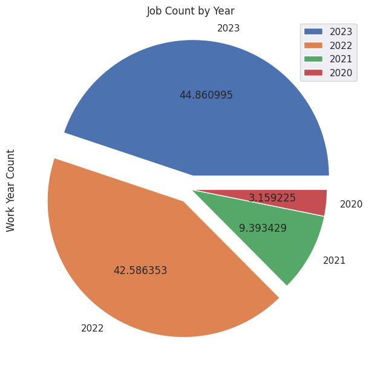

```python
plt.figure(figsize=(16,20))
plt.subplot(121)
df['work_year'].value_counts().plot(kind="pie",autopct="%2f",explode=(0.1,0.1,0,0))
plt.title('Job Count by Year')
plt.ylabel('Work Year Count')
plt.savefig("work_year.png")
plt.legend()
plt.show()
plt.savefig("work_year_distribution.png")
```

> From above numbers we can say that, we have

```
# A data from 2020 to 2023. Total we have 4 year of data.
```

> Based on above counts/data its looks like the requirement of data scientist increased as per years.

### 3.2 Experience Level

The Following lines of code demonstrate the count of job positions categorized by their level of experience in the field of data science.

```python
df['experience_level'].value_counts()
```

```
Senior-Level / Expert         1395
Mid-Level / Intermediate       623
Entry-Level / Junior           261
Executive-Level / Director      95
Name: experience_level, dtype: int64
```

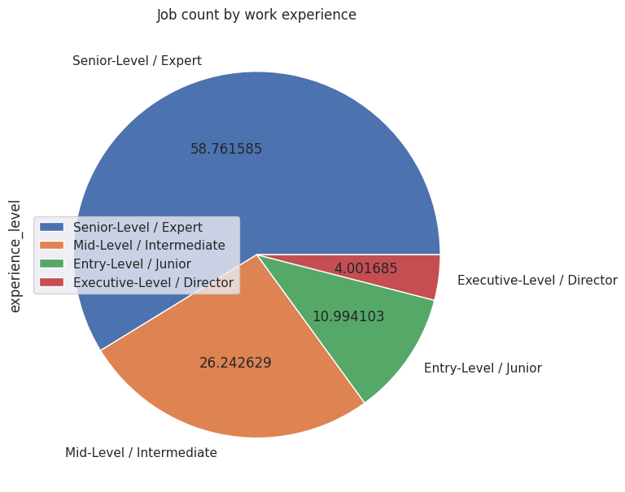

```python
plt.figure(figsize=(16,20))
plt.subplot(121)
df['experience_level'].value_counts().plot(kind="pie",autopct="%2f",explode=(0,0,0,0))
plt.title('Job count by work experience')
plt.savefig("exp_level.png")
plt.legend()
plt.show()
plt.savefig("exp_level_distribution.png")
```

### 3.3 Employment Type

The code below demonstrates the total count of job types present in our dataset.

```python
df['employment_type'].value_counts()
```

```
Full-Time    2337
Part-Time      17
Contract       10
Freelance      10
Name: employment_type, dtype: int64
```

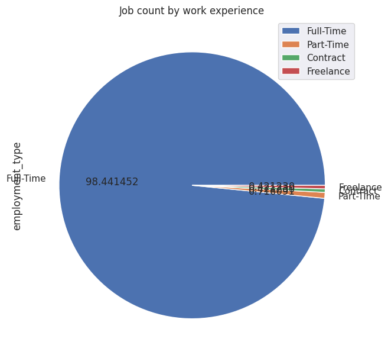

```python
plt.figure(figsize=(16,20))
plt.subplot(121)
df['employment_type'].value_counts().plot(kind="pie",autopct="%2f",explode=(0,0,0,0))
plt.title('Job count by work experience')
plt.savefig("employment_type.png")
plt.legend()
plt.show()
plt.savefig("employment_type_distribution.png")
```

> The graph and statistics above indicate a substantial higher number of job opportunities available for full-time employment in the field of data science.

### 3.4 Job Title

#### 3.4.a Job title with fewest no. of jobs

> We are going to visualize the job titles with the lowest number of job occurrences in our dataset.

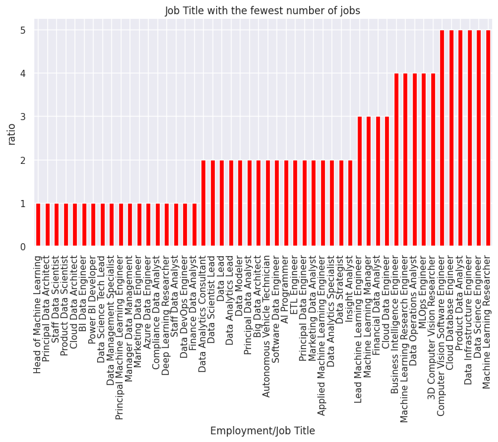

```python
df.employment_title.value_counts().nsmallest(50).plot(kind='bar',figsize=(10,5),color="red")
plt.title('Job Title with the fewest number of jobs')
plt.ylabel('ratio')
plt.xlabel('Employment/Job Title')
```

The dataset contains only one occurrence of the following job titles.

```python
df['employment_title'].value_counts()[df['employment_title'].value_counts() < 2]
```

```
Head of Machine Learning               1
Principal Data Architect               1
Staff Data Scientist                   1
Product Data Scientist                 1
Cloud Data Architect                   1
BI Data Engineer                       1
Power BI Developer                     1
Data Science Tech Lead                 1
Data Management Specialist             1
Principal Machine Learning Engineer    1
Manager Data Management                1
Marketing Data Engineer                1
Azure Data Engineer                    1
Compliance Data Analyst                1
Deep Learning Researcher               1
Staff Data Analyst                     1
Data DevOps Engineer                   1
Finance Data Analyst                   1
Name: employment_title, dtype: int64
```

#### 3.4.b Job title with highest no. of jobs

> We are going to visualize the job titles with the highest number of job occurrences in our dataset.

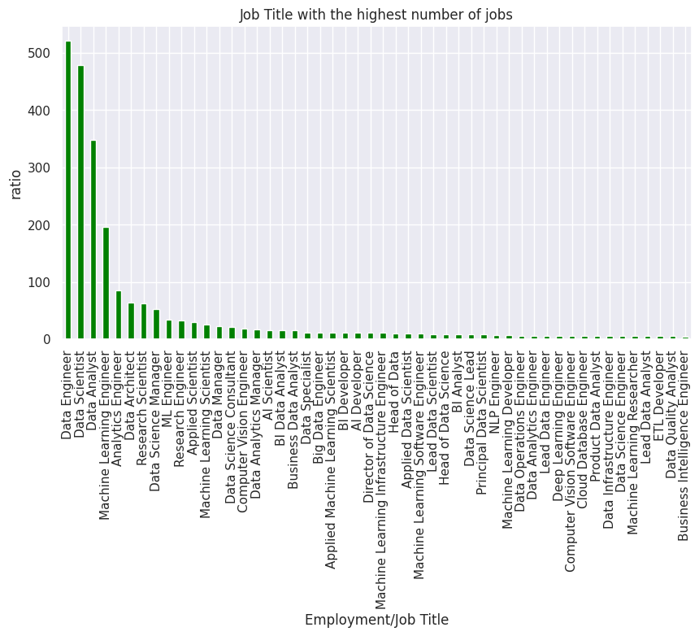

```python
df.employment_title.value_counts().nlargest(50).plot(kind='bar',figsize=(10,5),color="green")
plt.title('Job Title with the highest number of jobs')
plt.ylabel('ratio')
plt.xlabel('Employment/Job Title')
```

#### 3.4.c Top 10 highest No. of job in data science

The dataset reveals the visualization by the pie chart of the employment sector that has the highest number of jobs.

```python
df['employment_title'].value_counts().sort_values(ascending=False).head(10)
```

```
Data Engineer                521
Data Scientist               479
Data Analyst                 348
Machine Learning Engineer    196
Analytics Engineer            85
Data Architect                64
Research Scientist            63
Data Science Manager          52
ML Engineer                   34
Research Engineer             33
Name: employment_title, dtype: int64
```

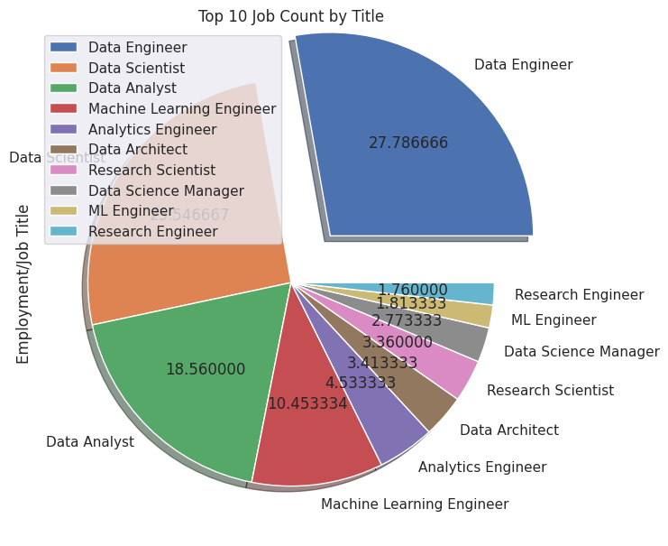

```python
plt.figure(figsize=(16,20))
plt.subplot(1,2,1)
df['employment_title'].value_counts().sort_values(ascending=False).head(10).plot(kind="pie",shadow=True,explode = (0.3,0,0,0,0,0,0,0,0,0),autopct="%2f")
plt.title('Top 10 Job Count by Title')
plt.ylabel('Employment/Job Title')
plt.legend()
plt.savefig("most_employment_title.png")
plt.show()
```

### 3.5 Employee Salary

The visualization of employees' salaries is necessary in order to identify any outliers within the dataset. To detect these outliers, it is essential to visualize salary column.

#### 3.5.a Detecting Outliers

##### Box Plot Before Removing Outliers

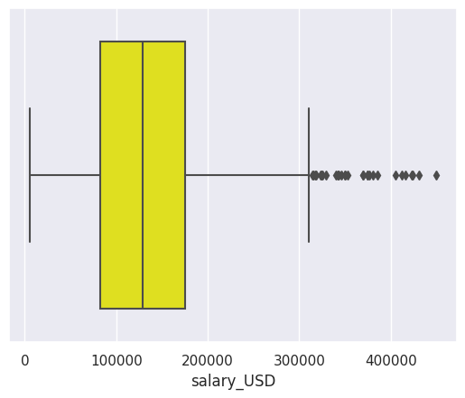

```python
sns.boxplot(x=df['salary_USD'], color = 'yellow')
```

> The box plot above illustrates that the majority of employee salaries fall under 200,000, while a few salaries are beyond the range of 300,000 that may become an outliers and if there are any outliers in our dataset, it is necessary to eliminate them by identifying the quantile in our dataset.

##### Removing Outliers

**Finding 1st Quartile, 3rd Quartile and Interquartile Range**

```python
Q1 = df.quantile(0.25, numeric_only = True)
Q3 = df.quantile(0.75, numeric_only = True)
IQR = Q3 - Q1
print('Q1(quantile - 0.25) = ', Q1)
print('----------------------------------------------')
print('Q3(quantile - 0.75) = ', Q3)
print('----------------------------------------------')
print('IQR(Q3 - Q1) = ', IQR)
```

```
Q1(quantile - 0.25) =  work_year      2022.0
salary_USD    82783.0
Name: 0.25, dtype: float64
----------------------------------------------
Q3(quantile - 0.75) =  work_year       2023.0
salary_USD    175100.0
Name: 0.75, dtype: float64
----------------------------------------------
IQR(Q3 - Q1) =  work_year         1.0
salary_USD    92317.0
dtype: float64
```

**Removing Outliers from dataframe**

```python
df_fix = df[~(((df < (Q1 - 1.5 *   IQR)) | (df > (Q3 + 1.5 *   IQR))).any(axis=1))]
df_fix.head(5)
```

|  | work_year | experience_level | employment_type | employment_title | salary_USD | employee_location | employment_location |
| --- | --- | --- | --- | --- | --- | --- | --- |
| 0 | 2023 | Senior-Level / Expert | Full-Time | Principal Data Scientist | 85847 | Spain | Spain |
| 1 | 2023 | Mid-Level / Intermediate | Contract | ML Engineer | 30000 | United States of America | United States of America |
| 2 | 2023 | Mid-Level / Intermediate | Contract | ML Engineer | 25500 | United States of America | United States of America |
| 3 | 2023 | Senior-Level / Expert | Full-Time | Data Scientist | 175000 | Canada | Canada |
| 4 | 2023 | Senior-Level / Expert | Full-Time | Data Scientist | 120000 | Canada | Canada |

**Dataset Shape before and after removing Outliers**

```python
#title Default title text
print("Dataset shape before removing Outliers :", df.shape)
print("Dataset shape before after Outliers :",  df_fix.shape)
print("Outliers Rows in dataset :", (df.size - df_fix.size))
df = df_fix
```

```
Dataset shape before removing Outliers : (2374, 7)
Dataset shape before after Outliers : (2273, 7)
Outliers Rows in dataset : 707
```

##### Box Plot After Removing Outliers

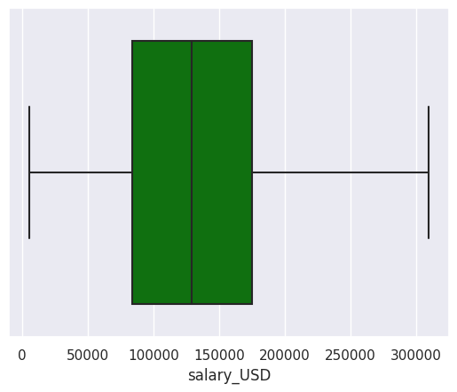

```python
sns.boxplot(x=df['salary_USD'], color = 'green')
```

#### 3.5.b Salary scattering

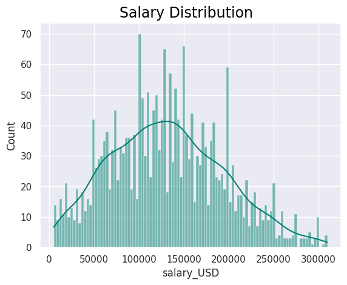

```python
plt.gcf().text(.33, .90,
               "Salary Distribution",
               fontsize = 17,
               color='Black')

sns.histplot(df['salary_USD'],
             bins=100,
             kde=True,
             color= '#008070'
             )

sns.set(rc={'xtick.labelsize':10,
            'ytick.labelsize':10})

plt.show()
```

### 3.6 Work Year and Salary

```python
df['work_year'].unique()
```

```
array([2023, 2022, 2021])
```

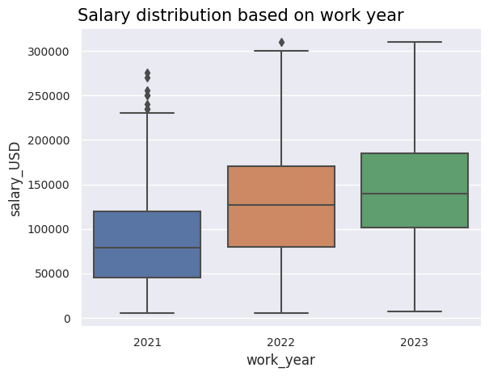

```python
fig, ax = plt.subplots(1, 1)
plt.gcf().text(.12, .90,
               "Salary distribution based on work year",
               fontsize = 15,
               color='Black')
sns.boxplot(x = 'work_year', y='salary_USD', data = df, ax =ax)
```

### 3.7 Job title and Salary

#### 3.7.a Highest Salary Job title

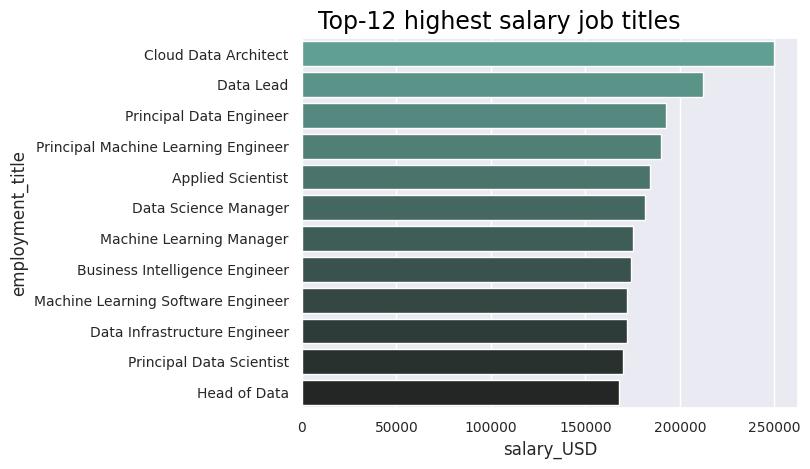

```python
data = df.groupby('employment_title').mean('numeric')['salary_USD'].reset_index().sort_values(by='salary_USD', ascending=False).head(12)
sns.barplot(y=data['employment_title'], x=data['salary_USD'], palette='dark:#5A9_r')

sns.set(rc={'xtick.labelsize':10,
            'ytick.labelsize':10})

plt.gcf().text(.15, .90,
               "Top-12 highest salary job titles",
               fontsize = 17,
               color='Black')
plt.show()
```

#### 3.7.b Lowest Salary Job title

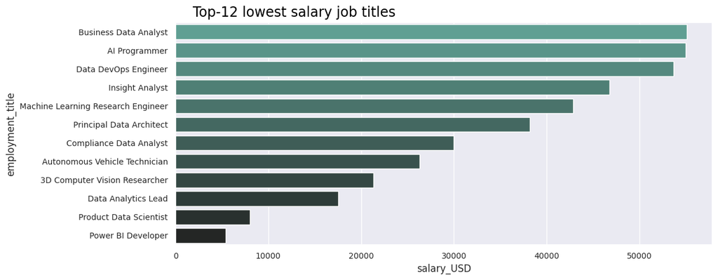

```python
plt.figure(figsize=(12,5))
data = df.groupby('employment_title').mean('numeric')['salary_USD'].reset_index().sort_values(by='salary_USD', ascending=False).tail(12)

sns.barplot(y=data['employment_title'], x=data['salary_USD'],palette='dark:#5A9_r')

sns.set(rc={'xtick.labelsize':10,
            'ytick.labelsize':10})

plt.gcf().text(.15, .90,
               "Top-12 lowest salary job titles",
               fontsize = 17,
               color='Black')
plt.show()
```

### 3.8 Experience Level and Salary

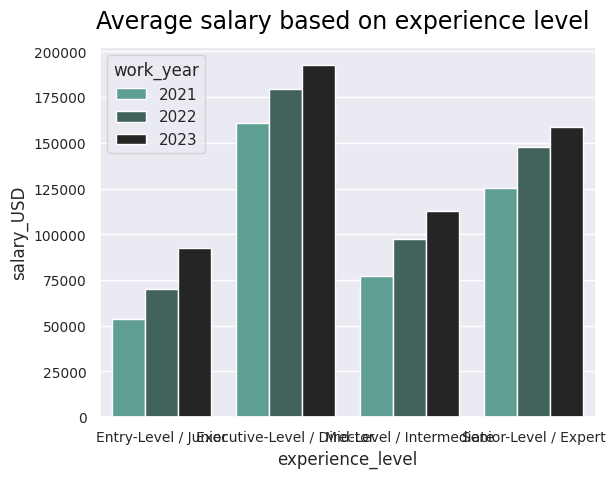

```python
data = df.groupby(['work_year', 'experience_level']).salary_USD.mean().reset_index()
sns.barplot(x= data['experience_level'], y= data['salary_USD'], hue= data['work_year'], palette='dark:#5A9_r')

sns.set(rc={'xtick.labelsize':7,
            'ytick.labelsize':10})
plt.gcf().text(.12, .92,
               "Average salary based on experience level",
               fontsize = 17,
               color='Black')

plt.show()
```

### 3.9 Employment Type and Salary

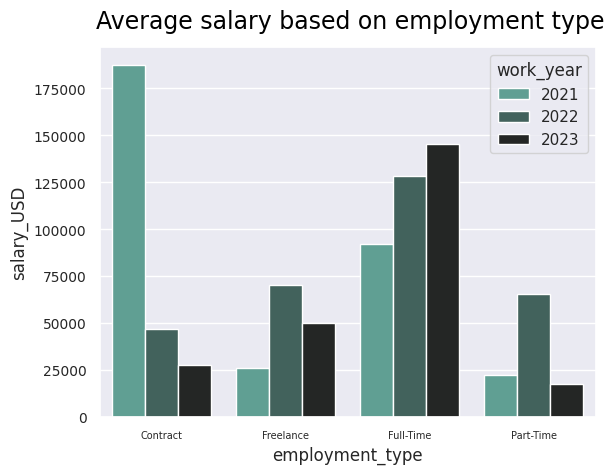

```python
data = df.groupby(['work_year', 'employment_type']).salary_USD.mean().reset_index()
sns.barplot(x= data['employment_type'], y= data['salary_USD'], hue= data['work_year'], palette='dark:#5A9_r')

sns.set(rc={'xtick.labelsize':10,
            'ytick.labelsize':10})

plt.gcf().text(.12, .92,
               "Average salary based on employment type",
               fontsize = 17,
               color='Black')


plt.show()
```

### 3.10 Job Location and Salary

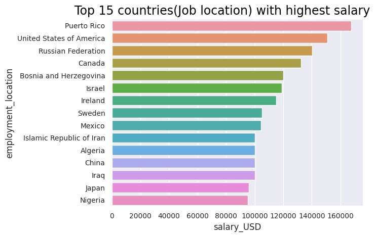

```python
data = df.groupby('employment_location').mean('numeric')['salary_USD'].reset_index().sort_values(by='salary_USD', ascending=False).head(15)
sns.barplot(y=data['employment_location'], x=data['salary_USD'])

sns.set(rc={'xtick.labelsize':10,
            'ytick.labelsize':10})

plt.gcf().text(.01, .90,
               "Top 15 countries(Job location) with highest salary",
               fontsize = 17,
               color='Black')
plt.show()
```

### 3.11 Employee Location and Salary

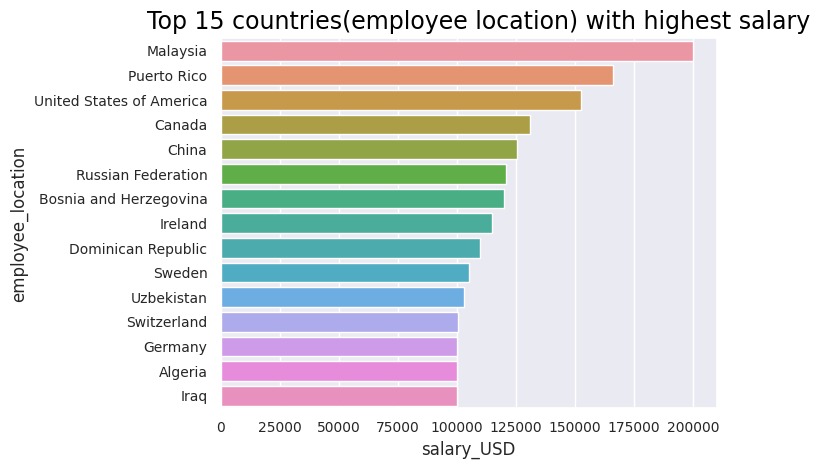

```python
data = df.groupby('employee_location').mean('numeric')['salary_USD'].reset_index().sort_values(by='salary_USD', ascending=False).head(15)
sns.barplot(y=data['employee_location'], x=data['salary_USD'])

sns.set(rc={'xtick.labelsize':10,
            'ytick.labelsize':10})

plt.gcf().text(.01, .90,
               "Top 15 countries(employee location) with highest salary",
               fontsize = 17,
               color='Black')
plt.show()
```

### 3.12 Coorelation Matrix Heatmap

```python
df_scaler = df.copy()
label_encoder = preprocessing.LabelEncoder()
features = ['employment_type','experience_level','employment_title','employee_location','employment_location']
for feature in features:
    label_encoder.fit(df_scaler[feature].unique())
    df_scaler[feature] = label_encoder.transform(df_scaler[feature])
    print(feature, df_scaler[feature].unique())
```

```
employment_type [2 0 1 3]
experience_level [3 2 0 1]
employment_title [83 65 46  8 25 38 87  4 18 68 49 33 23 41 22 31  6  1 88 29 17  5 54 32
 57 45 37 72 16 48 61 13 52 73 66  9  7 63 21 56 34 89  2 40 14 44 51 11
 42 30 69 12 58 60  3 50 74 15 85 24 10 77 28 35 43 71 78 75 67  0 84 27
 26 36 47 20 39 76 79 86 81 70 64 53 19 62 59 80 82 90 55]
employee_location [60 69 11 26 68 49 31 29 53 48 62 12 25  4 24 66 34 27  5 15 57 61 59 45
 70  9 63 17 52 39 71 18  2  3  8 38 28 72 40 55 50 36 47 41  6  1 35 30
 58 14 19 16 65 13 54 20  7 51 21 22 32 67 43 37 23 64 56  0 33 10 46 42
 44]
employment_location [59 67 12 25 66 48 30 28 47 61 13 24 23 64 33 26 16 56  5 60 58 44 11 52
 55 62 18 68 22  4 10 38 27 69 39 54 49 36 46 51  0  3 40  2 17 34  7 29
  6 57 19 63 53 20  9 50  8 31 21 65 41 42 37  1 32 15 14 45 35 43]
```

**Normalization**

> Converting Categorical to Numeric

```python
from sklearn.preprocessing import StandardScaler
scaler = StandardScaler()
df_scaler[['employment_type','experience_level','employment_title','employee_location','employment_location']] = scaler.fit_transform(df_scaler[['employment_type','experience_level','employment_title','employee_location','employment_location']])
df_scaler
```

|  | work_year | experience_level | employment_type | employment_title | salary_USD | employee_location | employment_location |
| --- | --- | --- | --- | --- | --- | --- | --- |
| 0 | 2023 | 0.673016 | 0.028040 | 2.142904 | 85847 | -0.054413 | -0.038632 |
| 1 | 2023 | -0.361308 | -12.718912 | 1.241957 | 30000 | 0.456902 | 0.441863 |
| 2 | 2023 | -0.361308 | -12.718912 | 1.241957 | 25500 | 0.456902 | 0.441863 |
| 3 | 2023 | 0.673016 | 0.028040 | 0.290957 | 175000 | -2.838240 | -2.861542 |
| 4 | 2023 | 0.673016 | 0.028040 | 0.290957 | 120000 | -2.838240 | -2.861542 |
| ... | ... | ... | ... | ... | ... | ... | ... |
| 3746 | 2021 | -0.361308 | 0.028040 | 0.290957 | 119059 | -0.224852 | -1.480118 |
| 3748 | 2021 | -0.361308 | 0.028040 | -0.359727 | 28369 | -0.963418 | -0.999623 |
| 3749 | 2021 | 0.673016 | 0.028040 | 0.391062 | 165000 | 0.456902 | 0.441863 |
| 3751 | 2021 | -0.361308 | 0.028040 | 2.142904 | 151000 | 0.456902 | 0.441863 |
| 3754 | 2021 | 0.673016 | 0.028040 | 0.240904 | 94665 | -1.701984 | -1.780428 |

2273 rows × 7 columns

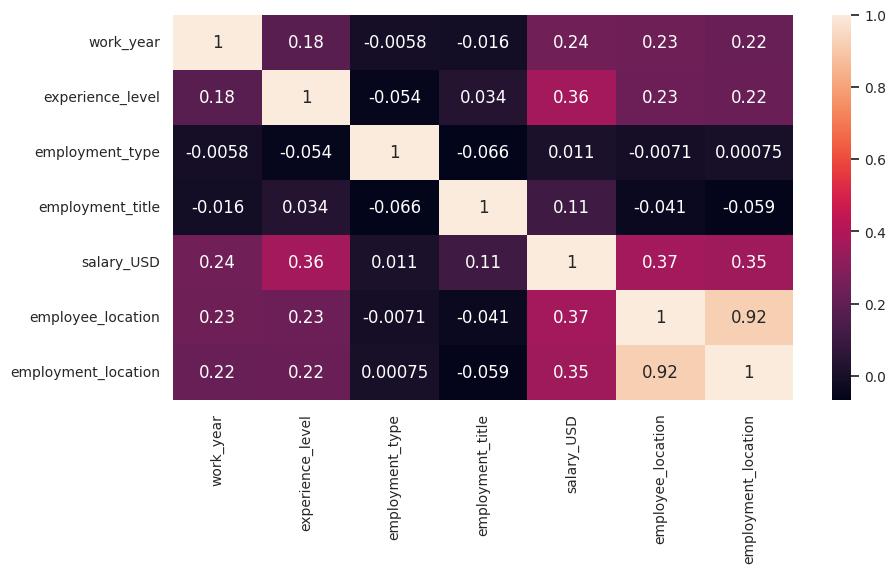

```python
plt.figure(figsize=(10,5))
sns.heatmap(df_scaler.corr(), annot=True)
```

> In this coorelation matrix, Following are the major coorealtions.
> - Employee Location and Salary(USD) - 0.37
> - Experience Level and Salary(USD) - 0.36
> - Job Location and Salary(USD) - 0.35
> - Work Year and Salary(USD) - 0.24
> - Work Year and Employee Location - 0.23
> - Experience Level and Employee Location - 0.23

> Salary with employee location is explored in the EDA **3.11**

> Salary with Experience level is explored in the EDA **3.8**

> Salary with job location is explored in the EDA **3.10**

> Salary with work year is explored in the EDA **3.6**

## 4 - MODELING

### Model Selection for salary prediction

We will be implementing several optimal machine learning models based on the specific needs of our project.

> To facilitate the advancement of our machine learning model for salary prediction in USD, we shall divide our dataframe into two distinct sets: train and test.

> I am going to set 75% of the data for the train set and 25% of the data for the test set by setting randome state to 42.

```python
scaler = StandardScaler()
df_scaler[['salary_USD']] = scaler.fit_transform(df_scaler[['salary_USD']])

X = df_scaler.drop(['salary_USD'], axis = 1)
y = df_scaler['salary_USD']
X_train, X_test, y_train, y_test = train_test_split(X, y, test_size = 0.25, random_state = 42)
X_train.shape, y_train.shape
```

```
((1704, 6), (1704,))
```

#### Model - Linear Regression

```python
model = LinearRegression()

#fit to trainig data
model.fit(X_train, y_train)

# Predicting test data using model
y_pred = model.predict(X_test)

# Calculate MSE
mse = mean_squared_error(y_test, y_pred)

# Calculate the coefficient of determination (R^2 score)
r2 = r2_score(y_test, y_pred)

print(f'MSE = {mse},\nR^2 score = {r2}')
```

```
MSE = 0.706341033650855,
R^2 score = 0.29302320519383984
```

```python
dfr = pd.DataFrame({'Actual': y_test, 'Predicted': y_pred})
dfr.reset_index(drop=True, inplace=True)
dfr.head(10)
```

|  | Actual | Predicted |
| --- | --- | --- |
| 0 | 0.052552 | 0.090341 |
| 1 | 1.548812 | 0.197573 |
| 2 | -1.651185 | -1.075766 |
| 3 | 0.192176 | 0.122784 |
| 4 | 1.092059 | 0.472379 |
| 5 | -0.968276 | 0.130481 |
| 6 | -0.590179 | 0.743077 |
| 7 | -0.656203 | -0.406435 |
| 8 | -0.498702 | 0.472379 |
| 9 | -0.010449 | 0.146011 |

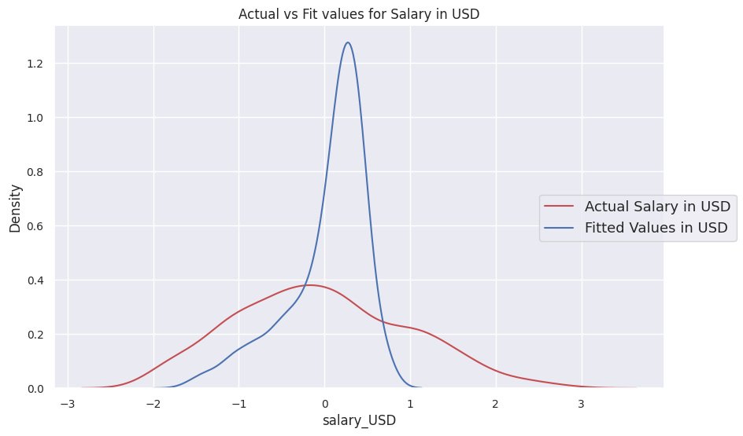

```python
ax, fig = plt.subplots(figsize= (10,6))
sns.kdeplot(y_test, color="r", label='Actual Salary in USD')
sns.kdeplot(y_pred, color="b", label='Fitted Values in USD')

plt.title('Actual vs Fit values for Salary in USD')
ax.legend(loc='center right', fontsize=13)

plt.show()
```

#### Model - Random Forest Regressor

```python
rf = RandomForestRegressor()

#fit to trainig data
rf.fit(X_train,y_train)

# Predicting test data using model
y_pred_val_rf = rf.predict(X_test)

# Calculate MSE
mse_rf = mean_squared_error(y_test, y_pred_val_rf)

# Calculate the coefficient of determination (R^2 score)
r2_rf = r2_score(y_test, y_pred_val_rf)

print(f'MSE = {mse_rf},\nR^2 score = {r2_rf}')
```

```
MSE = 0.5756273517108219,
R^2 score = 0.4238545394823636
```

```python
dfr = pd.DataFrame({'Actual': y_test, 'Predicted': y_pred_val_rf})
dfr.reset_index(drop=True, inplace=True)
dfr.head(10)
```

|  | Actual | Predicted |
| --- | --- | --- |
| 0 | 0.052552 | 0.494433 |
| 1 | 1.548812 | 0.397993 |
| 2 | -1.651185 | -1.249472 |
| 3 | 0.192176 | 0.097482 |
| 4 | 1.092059 | 0.616778 |
| 5 | -0.968276 | -0.859513 |
| 6 | -0.590179 | 0.536795 |
| 7 | -0.656203 | -0.373971 |
| 8 | -0.498702 | 0.616778 |
| 9 | -0.010449 | -0.168681 |

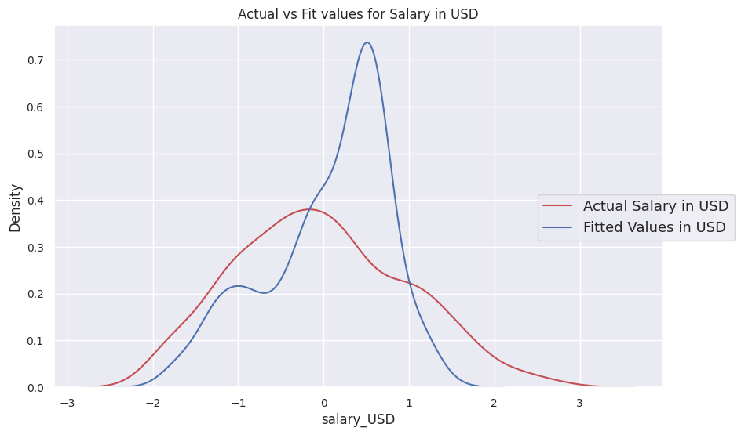

```python
ax, fig = plt.subplots(figsize= (10,6))
sns.kdeplot(y_test, color="r", label='Actual Salary in USD')
sns.kdeplot(y_pred_val_rf, color="b", label='Fitted Values in USD')

plt.title('Actual vs Fit values for Salary in USD')
ax.legend(loc='center right', fontsize=13)
```

### Job Recommendation

```python
indices_exLevel = pd.Series(df['experience_level'])
indices_empTitle =  pd.Series(df['employment_title'])
def TitleMatching(title):
  if title not in indices_exLevel.values:
    if title not in indices_empTitle.values:
      return ''
    else:
      return 'employment_title'
  else:
    return 'experience_level'
```

```python
def Recommendation(searchBy):
  title = TitleMatching(searchBy)
  if title != '':
    tf = TfidfVectorizer(analyzer = "word", ngram_range=(1,2), min_df=0, stop_words='english')
    tfidf_matrix = tf.fit_transform(df[title])
    cosine_sim =  cosine_similarity(tfidf_matrix, tfidf_matrix)
    indices = pd.Series(df[title])
    idx = indices[indices == searchBy].index[0]
    score_series = pd.Series(cosine_sim[idx]).sort_values(ascending = False)
    top_10_indices = list(score_series.iloc[1:11].index)
    return df.iloc[top_10_indices]
  else:
    return "Not found"
```

```python
result = Recommendation('ML Engineer')
if str(type(result)) != "<class 'str'>":
  idx = result.groupby(['employee_location','employment_title'])
  idxMax = idx['salary_USD'].idxmax()
  idxMin = idx['salary_USD'].idxmin()
  max_result = result.loc[idxMax]
  min_result = result.loc[idxMin]

  recommendationResult = '******** Job Recommendation ******** \n\n'
  for i in range(len(max_result)):
    obj_max = max_result.iloc[i]
    obj_min = min_result.iloc[i]
    salary_range = '$' + str(obj_max['salary_USD']) if (obj_max['salary_USD'] == obj_min['salary_USD']) else '$' + str(obj_min['salary_USD']) + ' - ' + '$' + str(obj_max['salary_USD'])
    recommendationResult += 'Job Title: ' + obj_max['employment_title'] + '\n' + 'Salary Range: '+ str(salary_range) + '\n' + 'Location: '+ obj_max['employment_location'] + '\n\n'
  print(recommendationResult)
```

```
******** Job Recommendation ********

Job Title: ML Engineer
Salary Range: $30000 - $289076
Location: United States of America
```

## 5- INSIGHT

**Location Based Analysis**

**Analysis Of Career Growth**

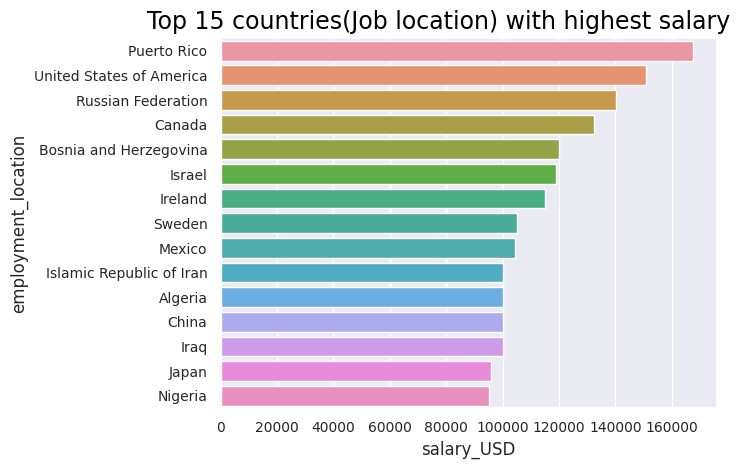

```python
data = df.groupby('employment_location').mean('numeric')['salary_USD'].reset_index().sort_values(by='salary_USD', ascending=False).head(15)
sns.barplot(y=data['employment_location'], x=data['salary_USD'])

sns.set(rc={'xtick.labelsize':10,
            'ytick.labelsize':10})

plt.gcf().text(.01, .90,
               "Top 15 countries(Job location) with highest salary",
               fontsize = 17,
               color='Black')
plt.show()
```